# STATS-PRELIM-EXPLOITATION

# 1 Overview

For these exploratory runs there were 50 objectives to optimize, all with the target of 100 and an accuracy requirement of 99%. The population was size 512, and there was a point mutation probability of .7% at each objective.

# 2 Mu Lambda Selection

Here we explore the impact of different Mu values on the exploitation diagnostic.

## 2.1 Generation Solution Found Data

### 2.1.1 Generation Optimal Solution Found Per Mu

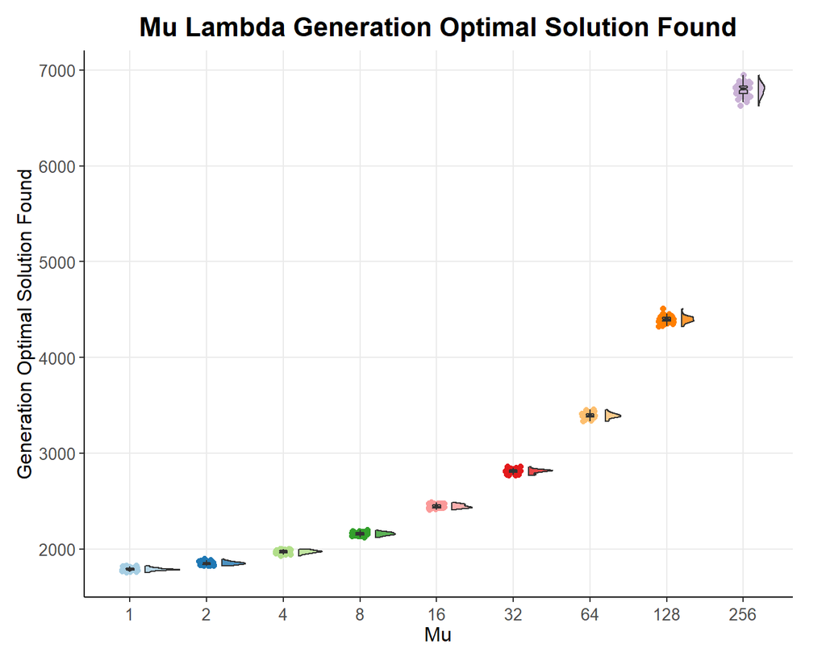

### 2.1.2 Summary Statistics

```r
do.call("rbind", tapply(df$Gen, df$Mu, summary))
```

```
##     Min. 1st Qu. Median    Mean 3rd Qu. Max.
## 1   1753 1779.25 1785.0 1787.40 1795.25 1826
## 2   1822 1839.25 1849.0 1849.72 1858.75 1892
## 4   1924 1961.25 1972.0 1970.54 1981.75 1999
## 8   2119 2147.00 2156.0 2156.90 2169.00 2194
## 16  2411 2430.00 2441.0 2445.02 2462.00 2488
## 32  2765 2801.25 2815.5 2811.42 2822.75 2860
## 64  3334 3376.75 3391.0 3391.36 3407.75 3454
## 128 4321 4379.25 4397.0 4396.72 4418.00 4508
## 256 6628 6754.50 6807.5 6794.10 6833.50 6947
```

### 2.1.3 Stats Tests

The Kuskal-Wallis test show evidence of statisticaly significant differences between Mu values.

```r
kruskal.test(Gen ~ Mu, data = df)
```

```
##
##  Kruskal-Wallis rank sum test
##
## data:  Gen by Mu
## Kruskal-Wallis chi-squared = 443.43, df = 8, p-value < 2.2e-16
```

The pairwaise Wilcoxon rank sum tests show evidence that Mu=1 is statsically lower than all other Mu values.

```r
pairwise.wilcox.test(x = df$Gen, g = df$Mu, p.adjust.method = "BH", paired = FALSE, conf.int = TRUE, conf.level = .95, alternative = 'g')
```

```
##
##  Pairwise comparisons using Wilcoxon rank sum test
##
## data:  df$Gen and df$Mu
##
##     1      2      4      8      16     32     64     128
## 2   <2e-16 -      -      -      -      -      -      -
## 4   <2e-16 <2e-16 -      -      -      -      -      -
## 8   <2e-16 <2e-16 <2e-16 -      -      -      -      -
## 16  <2e-16 <2e-16 <2e-16 <2e-16 -      -      -      -
## 32  <2e-16 <2e-16 <2e-16 <2e-16 <2e-16 -      -      -
## 64  <2e-16 <2e-16 <2e-16 <2e-16 <2e-16 <2e-16 -      -
## 128 <2e-16 <2e-16 <2e-16 <2e-16 <2e-16 <2e-16 <2e-16 -
## 256 <2e-16 <2e-16 <2e-16 <2e-16 <2e-16 <2e-16 <2e-16 <2e-16
##
## P value adjustment method: BH
```

Individual pairing tests validate that Mu=1 is the optimal value for exploitation. A sample estimate on difference in location for each of the Mu value pairs is also given.

```r
wilcox.test(filter(df, Mu == 1)$Gen, filter(df, Mu == 2)$Gen, p.adjust.method = "BH", paired = FALSE, conf.int = TRUE, conf.level = .95, alternative = 'l')
```

```
##
##  Wilcoxon rank sum test with continuity correction
##
## data:  filter(df, Mu == 1)$Gen and filter(df, Mu == 2)$Gen
## W = 6, p-value < 2.2e-16
## alternative hypothesis: true location shift is less than 0
## 95 percent confidence interval:
##       -Inf -57.00001
## sample estimates:
## difference in location
##              -62.00005
```

```r
wilcox.test(filter(df, Mu == 1)$Gen, filter(df, Mu == 4)$Gen, p.adjust.method = "BH", paired = FALSE, conf.int = TRUE, conf.level = .95, alternative = 'l')
```

```
##
##  Wilcoxon rank sum test with continuity correction
##
## data:  filter(df, Mu == 1)$Gen and filter(df, Mu == 4)$Gen
## W = 0, p-value < 2.2e-16
## alternative hypothesis: true location shift is less than 0
## 95 percent confidence interval:
##       -Inf -179.0001
## sample estimates:
## difference in location
##                   -185
```

```r
wilcox.test(filter(df, Mu == 1)$Gen, filter(df, Mu == 8)$Gen, p.adjust.method = "BH", paired = FALSE, conf.int = TRUE, conf.level = .95, alternative = 'l')
```

```
##
##  Wilcoxon rank sum test with continuity correction
##
## data:  filter(df, Mu == 1)$Gen and filter(df, Mu == 8)$Gen
## W = 0, p-value < 2.2e-16
## alternative hypothesis: true location shift is less than 0
## 95 percent confidence interval:
##  -Inf -365
## sample estimates:
## difference in location
##                   -370
```

```r
wilcox.test(filter(df, Mu == 1)$Gen, filter(df, Mu == 16)$Gen, p.adjust.method = "BH", paired = FALSE, conf.int = TRUE, conf.level = .95, alternative = 'l')
```

```
##
##  Wilcoxon rank sum test with continuity correction
##
## data:  filter(df, Mu == 1)$Gen and filter(df, Mu == 16)$Gen
## W = 0, p-value < 2.2e-16
## alternative hypothesis: true location shift is less than 0
## 95 percent confidence interval:
##  -Inf -651
## sample estimates:
## difference in location
##                   -656
```

```r
wilcox.test(filter(df, Mu == 1)$Gen, filter(df, Mu == 32)$Gen, p.adjust.method = "BH", paired = FALSE, conf.int = TRUE, conf.level = .95, alternative = 'l')
```

```
##
##  Wilcoxon rank sum test with continuity correction
##
## data:  filter(df, Mu == 1)$Gen and filter(df, Mu == 32)$Gen
## W = 0, p-value < 2.2e-16
## alternative hypothesis: true location shift is less than 0
## 95 percent confidence interval:
##   -Inf -1020
## sample estimates:
## difference in location
##                  -1027
```

```r
wilcox.test(filter(df, Mu == 1)$Gen, filter(df, Mu == 64)$Gen, p.adjust.method = "BH", paired = FALSE, conf.int = TRUE, conf.level = .95, alternative = 'l')
```

```
##
##  Wilcoxon rank sum test with continuity correction
##
## data:  filter(df, Mu == 1)$Gen and filter(df, Mu == 64)$Gen
## W = 0, p-value < 2.2e-16
## alternative hypothesis: true location shift is less than 0
## 95 percent confidence interval:
##   -Inf -1598
## sample estimates:
## difference in location
##                  -1604
```

```r
wilcox.test(filter(df, Mu == 1)$Gen, filter(df, Mu == 128)$Gen, p.adjust.method = "BH", paired = FALSE, conf.int = TRUE, conf.level = .95, alternative = 'l')
```

```
##
##  Wilcoxon rank sum test with continuity correction
##
## data:  filter(df, Mu == 1)$Gen and filter(df, Mu == 128)$Gen
## W = 0, p-value < 2.2e-16
## alternative hypothesis: true location shift is less than 0
## 95 percent confidence interval:
##   -Inf -2601
## sample estimates:
## difference in location
##                  -2609
```

```r
wilcox.test(filter(df, Mu == 1)$Gen, filter(df, Mu == 256)$Gen, p.adjust.method = "BH", paired = FALSE, conf.int = TRUE, conf.level = .95, alternative = 'l')
```

```
##
##  Wilcoxon rank sum test with continuity correction
##
## data:  filter(df, Mu == 1)$Gen and filter(df, Mu == 256)$Gen
## W = 0, p-value < 2.2e-16
## alternative hypothesis: true location shift is less than 0
## 95 percent confidence interval:
##   -Inf -4993
## sample estimates:
## difference in location
##                  -5014
```

# 3 Tournament Selection

Here we explore the impact of different tournament size values on the exploitation diagnostic.

## 3.1 Generation Solution Found Data

### 3.1.1 Generation Optimal Solution Found Per Tournament Size

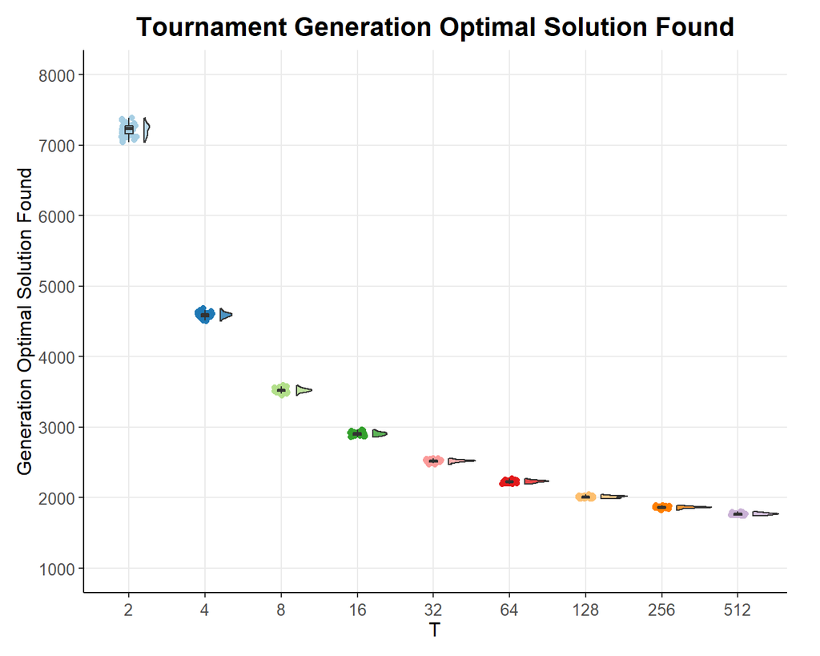

### 3.1.2 Summary Statistics

```r
do.call("rbind", tapply(df$Gen, df$T, summary))
```

```
##     Min. 1st Qu. Median    Mean 3rd Qu. Max.
## 2   7044 7164.75 7241.0 7219.42 7277.75 7388
## 4   4501 4568.50 4591.5 4592.38 4612.00 4691
## 8   3453 3507.25 3523.0 3524.08 3539.50 3593
## 16  2861 2886.50 2905.0 2906.50 2924.00 2963
## 32  2468 2510.00 2522.5 2520.20 2531.00 2559
## 64  2195 2219.00 2231.5 2229.70 2242.00 2270
## 128 1987 1995.00 2014.5 2010.82 2023.00 2044
## 256 1819 1857.00 1863.5 1863.50 1871.75 1891
## 512 1742 1757.25 1768.5 1768.82 1779.00 1802
```

### 3.1.3 Stats Tests

The Kuskal-Wallis test show evidence of statisticaly significant differences between tournament sizes

```r
kruskal.test(Gen ~ T, data = df)
```

```
##
##  Kruskal-Wallis rank sum test
##
## data:  Gen by T
## Kruskal-Wallis chi-squared = 443.46, df = 8, p-value < 2.2e-16
```

The pairwaise Wilcoxon rank sum tests show evidence that a tournmanet of size 512 is statsically lower than all other tournament sizes.

```r
pairwise.wilcox.test(x = df$Gen, g = df$T, p.adjust.method = "BH", paired = FALSE, conf.int = TRUE, conf.level = .95, alternative = 'l')
```

```
##
##  Pairwise comparisons using Wilcoxon rank sum test
##
## data:  df$Gen and df$T
##
##     2      4      8      16     32     64     128    256
## 4   <2e-16 -      -      -      -      -      -      -
## 8   <2e-16 <2e-16 -      -      -      -      -      -
## 16  <2e-16 <2e-16 <2e-16 -      -      -      -      -
## 32  <2e-16 <2e-16 <2e-16 <2e-16 -      -      -      -
## 64  <2e-16 <2e-16 <2e-16 <2e-16 <2e-16 -      -      -
## 128 <2e-16 <2e-16 <2e-16 <2e-16 <2e-16 <2e-16 -      -
## 256 <2e-16 <2e-16 <2e-16 <2e-16 <2e-16 <2e-16 <2e-16 -
## 512 <2e-16 <2e-16 <2e-16 <2e-16 <2e-16 <2e-16 <2e-16 <2e-16
##
## P value adjustment method: BH
```

```r
wilcox.test(filter(df, T == 512)$Gen, filter(df, T == 256)$Gen, p.adjust.method = "BH", paired = FALSE, conf.int = TRUE, conf.level = .95, alternative = 'l')
```

```
##
##  Wilcoxon rank sum test with continuity correction
##
## data:  filter(df, T == 512)$Gen and filter(df, T == 256)$Gen
## W = 0, p-value < 2.2e-16
## alternative hypothesis: true location shift is less than 0
## 95 percent confidence interval:
##       -Inf -90.99996
## sample estimates:
## difference in location
##              -95.00002
```

```r
wilcox.test(filter(df, T == 512)$Gen, filter(df, T == 128)$Gen, p.adjust.method = "BH", paired = FALSE, conf.int = TRUE, conf.level = .95, alternative = 'l')
```

```
##
##  Wilcoxon rank sum test with continuity correction
##
## data:  filter(df, T == 512)$Gen and filter(df, T == 128)$Gen
## W = 0, p-value < 2.2e-16
## alternative hypothesis: true location shift is less than 0
## 95 percent confidence interval:
##  -Inf -237
## sample estimates:
## difference in location
##                   -243
```

```r
wilcox.test(filter(df, T == 512)$Gen, filter(df, T == 64)$Gen, p.adjust.method = "BH", paired = FALSE, conf.int = TRUE, conf.level = .95, alternative = 'l')
```

```
##
##  Wilcoxon rank sum test with continuity correction
##
## data:  filter(df, T == 512)$Gen and filter(df, T == 64)$Gen
## W = 0, p-value < 2.2e-16
## alternative hypothesis: true location shift is less than 0
## 95 percent confidence interval:
##  -Inf -456
## sample estimates:
## difference in location
##              -461.9999
```

```r
wilcox.test(filter(df, T == 512)$Gen, filter(df, T == 32)$Gen, p.adjust.method = "BH", paired = FALSE, conf.int = TRUE, conf.level = .95, alternative = 'l')
```

```
##
##  Wilcoxon rank sum test with continuity correction
##
## data:  filter(df, T == 512)$Gen and filter(df, T == 32)$Gen
## W = 0, p-value < 2.2e-16
## alternative hypothesis: true location shift is less than 0
## 95 percent confidence interval:
##  -Inf -747
## sample estimates:
## difference in location
##                   -752
```

```r
wilcox.test(filter(df, T == 512)$Gen, filter(df, T == 32)$Gen, p.adjust.method = "BH", paired = FALSE, conf.int = TRUE, conf.level = .95, alternative = 'l')
```

```
##
##  Wilcoxon rank sum test with continuity correction
##
## data:  filter(df, T == 512)$Gen and filter(df, T == 32)$Gen
## W = 0, p-value < 2.2e-16
## alternative hypothesis: true location shift is less than 0
## 95 percent confidence interval:
##  -Inf -747
## sample estimates:
## difference in location
##                   -752
```

```r
wilcox.test(filter(df, T == 512)$Gen, filter(df, T == 8)$Gen, p.adjust.method = "BH", paired = FALSE, conf.int = TRUE, conf.level = .95, alternative = 'l')
```

```
##
##  Wilcoxon rank sum test with continuity correction
##
## data:  filter(df, T == 512)$Gen and filter(df, T == 8)$Gen
## W = 0, p-value < 2.2e-16
## alternative hypothesis: true location shift is less than 0
## 95 percent confidence interval:
##   -Inf -1748
## sample estimates:
## difference in location
##                  -1755
```

```r
wilcox.test(filter(df, T == 512)$Gen, filter(df, T == 4)$Gen, p.adjust.method = "BH", paired = FALSE, conf.int = TRUE, conf.level = .95, alternative = 'l')
```

```
##
##  Wilcoxon rank sum test with continuity correction
##
## data:  filter(df, T == 512)$Gen and filter(df, T == 4)$Gen
## W = 0, p-value < 2.2e-16
## alternative hypothesis: true location shift is less than 0
## 95 percent confidence interval:
##   -Inf -2815
## sample estimates:
## difference in location
##                  -2824
```

```r
wilcox.test(filter(df, T == 512)$Gen, filter(df, T == 2)$Gen, p.adjust.method = "BH", paired = FALSE, conf.int = TRUE, conf.level = .95, alternative = 'l')
```

```
##
##  Wilcoxon rank sum test with continuity correction
##
## data:  filter(df, T == 512)$Gen and filter(df, T == 2)$Gen
## W = 0, p-value < 2.2e-16
## alternative hypothesis: true location shift is less than 0
## 95 percent confidence interval:
##   -Inf -5434
## sample estimates:
## difference in location
##              -5467.612
```

# 4 Epsilon Lexicase Selection

Here we explore the impact of different epsilon values on the exploitation diagnostic.

## 4.1 Generation Solution Found Data

### 4.1.1 Generation Optimal Solution Found Per Epsilon

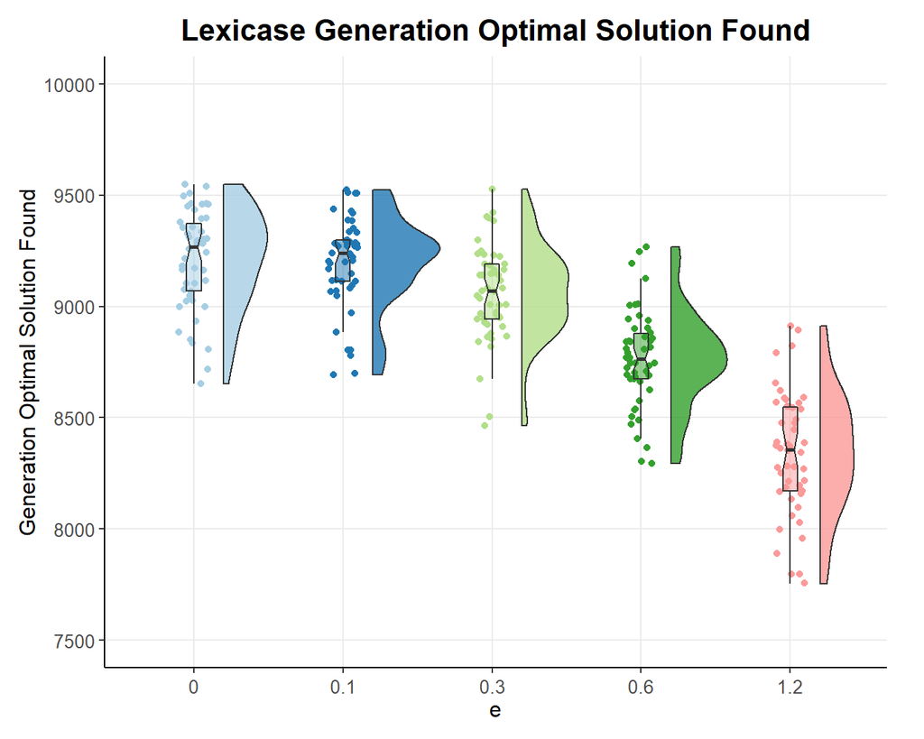

### 4.1.2 Summary Statistics

```r
# GET STATS BETWEEN EACH e
do.call("rbind", tapply(df$Gen, df$e, summary))
```

```
##     Min. 1st Qu. Median    Mean 3rd Qu. Max.
## 0   8653 9069.25 9269.0 9211.04 9374.00 9550
## 0.1 8694 9112.50 9239.5 9199.94 9298.00 9525
## 0.3 8464 8943.25 9069.0 9059.54 9189.75 9526
## 0.6 8293 8673.25 8765.0 8765.60 8877.25 9268
## 1.2 7755 8171.00 8357.5 8339.64 8549.00 8912
```

### 4.1.3 Stats Tests

The Kuskal-Wallis test show evidence of statisticaly significant differences between epsilon values.

```r
kruskal.test(Gen ~ e, data = df)
```

```
##
##  Kruskal-Wallis rank sum test
##
## data:  Gen by e
## Kruskal-Wallis chi-squared = 160.1, df = 4, p-value < 2.2e-16
```

The pairwaise Wilcoxon rank sum tests show evidence that an epsilon value of 1.2 is statsically lower than all other epsilon values.

```r
pairwise.wilcox.test(x = df$Gen, g = df$e, p.adjust.method = "BH", paired = FALSE, conf.int = TRUE, conf.level = .95, alternative = 'l')
```

```
##
##  Pairwise comparisons using Wilcoxon rank sum test
##
## data:  df$Gen and df$e
##
##     0       0.1     0.3     0.6
## 0.1 0.31470 -       -       -
## 0.3 0.00034 0.00021 -       -
## 0.6 8.7e-13 8.7e-13 1.8e-09 -
## 1.2 < 2e-16 < 2e-16 2.4e-16 2.1e-11
##
## P value adjustment method: BH
```

```r
# Hodges–Lehmann Estimator
wilcox.test(filter(df, e == 1.2)$Gen, filter(df, e == 0.0)$Gen, p.adjust.method = "BH", paired = FALSE, conf.int = TRUE, conf.level = .95, alternative = 'l')
```

```
##
##  Wilcoxon rank sum test with continuity correction
##
## data:  filter(df, e == 1.2)$Gen and filter(df, e == 0)$Gen
## W = 18, p-value < 2.2e-16
## alternative hypothesis: true location shift is less than 0
## 95 percent confidence interval:
##  -Inf -796
## sample estimates:
## difference in location
##                   -886
```

```r
wilcox.test(filter(df, e == 1.2)$Gen, filter(df, e == 0.1)$Gen, p.adjust.method = "BH", paired = FALSE, conf.int = TRUE, conf.level = .95, alternative = 'l')
```

```
##
##  Wilcoxon rank sum test with continuity correction
##
## data:  filter(df, e == 1.2)$Gen and filter(df, e == 0.1)$Gen
## W = 20, p-value < 2.2e-16
## alternative hypothesis: true location shift is less than 0
## 95 percent confidence interval:
##       -Inf -785.9999
## sample estimates:
## difference in location
##              -874.9999
```

```r
wilcox.test(filter(df, e == 1.2)$Gen, filter(df, e == 0.3)$Gen, p.adjust.method = "BH", paired = FALSE, conf.int = TRUE, conf.level = .95, alternative = 'l')
```

```
##
##  Wilcoxon rank sum test with continuity correction
##
## data:  filter(df, e == 1.2)$Gen and filter(df, e == 0.3)$Gen
## W = 51, p-value < 2.2e-16
## alternative hypothesis: true location shift is less than 0
## 95 percent confidence interval:
##  -Inf -641
## sample estimates:
## difference in location
##                   -716
```

```r
wilcox.test(filter(df, e == 1.2)$Gen, filter(df, e == 0.6)$Gen, p.adjust.method = "BH", paired = FALSE, conf.int = TRUE, conf.level = .95, alternative = 'l')
```

```
##
##  Wilcoxon rank sum test with continuity correction
##
## data:  filter(df, e == 1.2)$Gen and filter(df, e == 0.6)$Gen
## W = 281.5, p-value = 1.251e-11
## alternative hypothesis: true location shift is less than 0
## 95 percent confidence interval:
##  -Inf -336
## sample estimates:
## difference in location
##              -421.3795
```